# Model structure and generating synthetic data

Patrick Walker and Sequoia Leuba

2025-07-10

In this vignette we highlight key aspects of our underlying model and how to generate datasets with which to test our inferential framework

## Importing pre-calculated values

Our analysis uses an existing model to capture likely patterns of prior exposure by gravidity based upon patterns of fertility and Primigravid prevalence at first ANC

```r
list_inf_histories<-readRDS(here::here("inst", "extdata", "site_inf_histories.rds"))
knitr::kable(head(list_inf_histories$details))
```

| Study | Country | fert_pattern_code | SurveyYear | Province |
| --- | --- | --- | --- | --- |
| Wafrica_ISTp | Burkina | 1 | 2010 | Plateau Central |
| Wafrica_ISTp | Gambia | 2 | 2013 | Basse |
| Wafrica_ISTp | Ghana | 3 | 2008 | Upper East |
| Wafrica_ISTp | Mali | 8 | 2012 | Bamako |
| IMPROVE | Kenya | 4 | 2020 | Nyanza |
| IMPROVE | Malawi | 6 | 2012 | Southern |

Here we can see the closest available DHS survey year and admin1 unit the underlying fertility patterns are based upon. Selecting the first (representing the fertility patterns at the time of the trial of ISTp in Burkina Faso) we can look at it’s structure.

```r
selected_inf_history<-list_inf_histories$site_inf_history[[1]]
names(selected_inf_history)
```

```
#> [1] "sim_details" "inf_mat_g2"  "inf_mat_g3"  "inf_mat_g4"  "inf_mat_g5"
#> [6] "inf_mat_g6"
```

```r
knitr::kable(head(selected_inf_history$sim_details))
```

| EIR | primi_ANC_prev |
| --- | --- |
| 0.0316228 | 0.0125094 |
| 0.0319525 | 0.0125028 |
| 0.0322856 | 0.0127822 |
| 0.0326222 | 0.0128970 |
| 0.0329623 | 0.0130976 |
| 0.0333060 | 0.0130370 |

```r
knitr::kable(head(selected_inf_history$inf_mat_g2))
```

| inf_0 | inf_1 |
| --- | --- |
| 0.9530031 | 0.0469969 |
| 0.9498408 | 0.0501592 |
| 0.9530836 | 0.0469164 |
| 0.9517876 | 0.0482124 |
| 0.9485513 | 0.0514487 |
| 0.9513139 | 0.0486861 |

So if we want to see what the distribution of exposures of women infected during their second or third pregnancy in a setting with 10% prevalence by PCR at first ANC we use ‘sim_details’ as our look-up table and use that to access the correct row of ‘inf_mat_g2’ and ’inf_mat_g3’respectively

```r
primi_prev<-0.1
 index <- which.min(abs(selected_inf_history$sim_details$primi_ANC_prev - primi_prev))
  selected_inf_history$inf_mat_g2[index,]
```

```
#>         inf_0     inf_1
#> 239 0.7537347 0.2462653
```

```r
  selected_inf_history$inf_mat_g3[index,]
```

```
#>         inf_0     inf_1      inf_2
#> 239 0.5902863 0.3384354 0.07127827
```

So for infected secundigravidae we’d expect around 25% to have been exposed to malaria in their first pregnancy. At first glance this may seem unintuitively high given prevalence was 10% at first ANC in their previous pregnancy. In part this is because the model capture cumulative prevalence from 12 weeks gestation (when the placenta is considered sufficiently viable to lead to substantial sequestration) to delivery but is largely due to heterongeneity in exposure within the community - women who are infected last pregnancy are more likely than average to be infected this one.

To model how prior exposure mitigates the malaria-associated impact on hemoglobin, we use a sigmoidal function, which is commonly used in biological contexts to describe saturation effects.

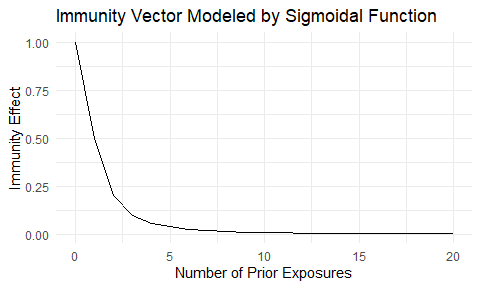

```r
# Example usage of the sigmoidal function
shape <- 2
scale <- 1
immunity_vector <- Sigmoid_func(0:20, shape, scale)



# Plot the sigmoidal function
library(ggplot2)
ggplot(data.frame(i = 0:20, immunity = immunity_vector), aes(x = i, y = immunity)) +
  geom_line() +
  labs(title = "Immunity Vector Modeled by Sigmoidal Function",
       x = "Number of Prior Exposures",
       y = "Immunity Effect") +
  theme_minimal()
```

We can integrate the immunity vector over the distribution of exposure to get a weighted effect of immunity by gravidity for a given ANC primigravid prevalence using the function get_weight_impact_df.

```r
# Assuming primi_prev is given and selected_inf_history is loaded
imm_vect <- Sigmoid_func(0:20, shape = 2, scale = 3)
 get_weight_impact_df(
  inf_history = selected_inf_history,
  primi_prev = 0.1,
  imm_vect = imm_vect
)
```

```
#> [1] 1.0000000 0.9753735 0.9442247 0.9105339 0.8758834 0.8038266
```

```r
  get_weight_impact_df(
  inf_history = selected_inf_history,
  primi_prev = 0.5,
  imm_vect = imm_vect
)
```

```
#> [1] 1.0000000 0.9267884 0.8083318 0.6939608 0.5941836 0.4438624
```

## Generating a test dataset

The function ‘generate_synthetic_data’ allows us to generate synthetic data which captures the impact of malaria throughout pregnancy in non-immune women and the immune effects as modelled above. It also captures shifts in haemoglobin dynamics that occur naturally by gravidity and through gestation in non-infected women.

```r
synthetic_data<-generate_synthetic_data(site_inf_history=selected_inf_history)

## returns a data frame of the individual level data and the malaria impact spline and effects of pregnancy-specific immmunity used within the simulation
names(synthetic_data)
```

```
#> [1] "data_df"             "simmed_mal_spline"   "simmed_mal_immunity"
#> [4] "grav_cats"
```

```r
# Display the first few rows of the synthetic data
knitr::kable(head(synthetic_data$data_df))
```

| gravidity | gestage | adj_gestage | malaria | hb_level |
| --- | --- | --- | --- | --- |
| 1 | 85 | 6 | 0 | 10.340820 |
| 1 | 191 | 112 | 0 | 9.082621 |
| 1 | 169 | 90 | 0 | 9.376975 |
| 1 | 139 | 60 | 1 | 7.204486 |
| 1 | 97 | 18 | 1 | 12.424056 |
| 1 | 119 | 40 | 0 | 10.791380 |

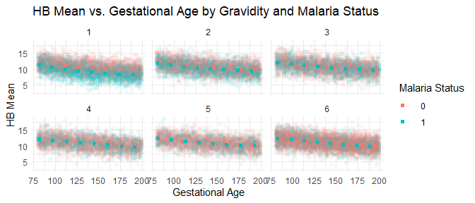

```r
### plot the dataset
ggplot(synthetic_data$data_df)+
geom_point( aes(x = gestage, y = hb_level, color = factor(malaria)), alpha = 0.05) +
  stat_smooth(data = synthetic_data$data_df, aes(x = gestage, y = hb_level, color = factor(malaria)), method = "loess", se = FALSE, linetype = "dotted", size = 2) +
  labs(title = "HB Mean vs. Gestational Age by Gravidity and Malaria Status",
       x = "Gestational Age",
       y = "HB Mean",
       color = "Malaria Status") +
  facet_wrap(~ gravidity) +
  theme_minimal()
```

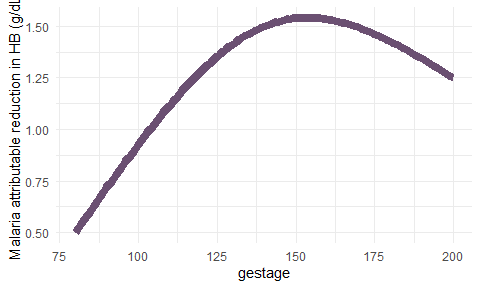

```r
# Plot malaria-attributable reduction in HB over gestational age in non-immune
ggplot(synthetic_data$simmed_mal_spline)+
  geom_line(aes(x = gestage, y = mal_effect), linewidth = 3,color = "#6B5072") +
  ylab("Malaria attributable reduction in HB (g/dL)") +
  theme_minimal()
```

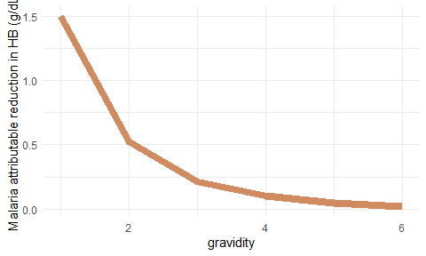

```r
### plot how this varies by gravidity
ggplot(synthetic_data$simmed_mal_immunity) +
  geom_line(aes(x = gravidity, y = mal_effect), linewidth = 3,color = "#D08C60") +
  ylab("Malaria attributable reduction in HB (g/dL)") +
  theme_minimal()
```